# Your Digest for Monday, Jul 24, 2023 11:59 PM

1. Gestational hypertension -
   1. Onset of hypertension (SBP>140 or DBP > 90) on two occasions more than 4 hours apart in *a previously normotensive individual*, **after 20 weeks of POA** and no proteinuria or signs of preeclampsia
2. Pre-eclampsia
   1. The above criteria **AND**
   2. **proteinuria** (>300mg / day or UPCR > 0.3)
3. Pre-eclampsia with severe features: Pre-clampsia with any of the following features or organ dysfunction:
   1. SBP > 160 OR DBP > 110
   2. *Haematology*: Thrombocytopaenai < 100,000
   3. *Liver*:Impaired liver function (either RUQ pain or enzyme levels > x2 of normal)
   4. *Kidney*:progressive renal dysfunction (rising S.Cr)
   5. *Pulmonary*: Pulmonary oedema
   6. *Brain*: Persistent cerebral or visual disturbances
4. Eclampsia
   1. Presence of a generalized seisure in a patient with eclampsia
5. HELLP syndrome
   1. Haemolysis
   2. Eleveted liver enzmes
   3. Low platelets
   4. *In HELLP, hemolysis, elevated liver enzymes, and thrombocytopenia are the predominant features* rather than hypertension or central nervous system or renal dysfunction, which can also occur.
6. Chronic hypertension:
   1. Hypertension diagnosed or present before pregnancy or on at least two occasions *before 20 weeks of gestation*. Hypertension that is *first diagnosed during pregnancy* and **persists for at least 12 weeks post-delivery** is also considered chronic hypertension.

## Acute fatty liver of pregnancy

> There is considerable overlap between acute fatty liver of pregnancy (AFLP) and preeclampsia with severe features/HELLP. Differentiation can be very difficult.

But the difference is important because AFLP patients can rapidly develop liver failure, encephalopathy and hypoglycaemia.  
Presents in T3, just like HELLP.

# Erythema marginatum

Seen most commonly in early stages of acute rheumatic fever [[Bacterial pathogens#GAS]].  
Middle of the lesion shows resolution. External edge is sharp, internal edge is blurred.  
Present on limbs and trunk but *not* the face.  
Also seen in hereditary angiooedema and psitaccosis. [Source](https://www.ncbi.nlm.nih.gov/books/NBK557835/)

# Erythema mulforme

[figure not shown]

"Short lived, acute, painless, immune mediated condition. ""  
90% of cases are triggered by infection; commonest is **HSV** infection. Mycoplasma infection is another cause.  
Distribution: Extensor surfaces of the distal limbs. Rash appears in 3-5 days after the infection and spreads centripetally; dissapears in about 2 weeks.  
Lesions are usually asymptomatic; itching and pain are uncommon.

Can be fatal without antibiotics.

# Rocky mountain spotted fever

Tick borne disease which can be *fatal* if untreated.  
*Ricketsia rickettsii* - gram negative obligate intracellular pathogen; infects vascular endothelial cells; causes vasculitis and increased capillary permeability.

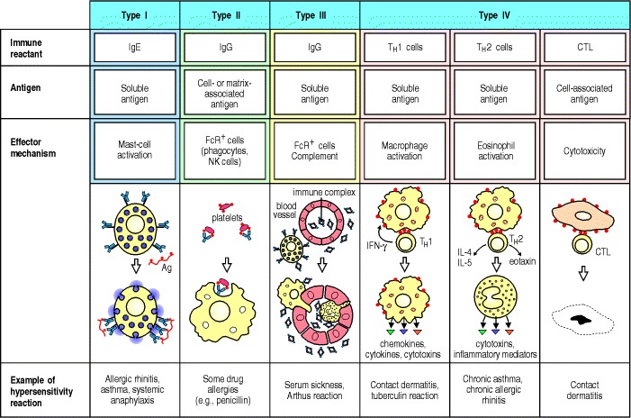

[output not shown]

> [!TIP] Hypersensitivity Vs Autoimmune disease  
> Hypersensitivity is an abnormal immune response to a harmless stimulus. When the 'stimulus' is a self antigen, we call it autoimmunity.

> > Autoimmune diseases can be classified in the same way as hypersensitivity conditions. but **IgE** is not involved in autoimmunity.  
> > so in the bale below, there is no "type I" in the autoimmune categories

## Autoimmune diseases examples

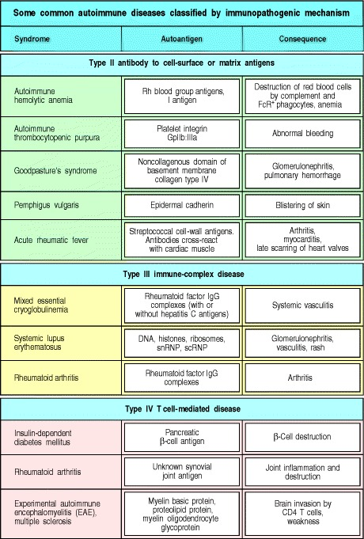

Infection occurs by ingestion of mature cysts from water or foods with *faecal* contamination.  
Cysts excystation in the small intestine and trophozoites migrate to the large intestine.  
There, they can cause asymptomatic colonization and produce cysts which are shed with faeces, spreading infection.  
They can also penetrate the protective mucous layer and **invade the mucosa**, causing symptomatic illness.  
Symtoms have subacute onset and can range from mild diarrhoea to severe dysentery.  
From the mucosa, the amoeba can invade the nearby blood vessels and disseminate to other tissues via the blood stream -> **extraintestinal disease**.  
**Commonly involved sites:**

1. liver -> liver abscesses can rupture into adjacent organs (heart and lungs)
2. lungs
3. brain

More prevalent in areas with poor hygiene and sanitation.

## Diagnosis of amoebiasis

Usually by stool microscopy but it cannot distinguish between pathogenic and non pathogenic species of entamoeba as they are morphologically identical.  
PCR is available and can identify the species.  
Serology will not distinguish between past infection and acute infection.

## Treatment of amoebiasis

For all infection: Intraluminal drug: paromoycin - acts directly on amoeba, poor oral absorption. (100% excreted in faeces)  
For symptomatic infections: metronidazole or tinidazole.

## Cutaneous manifestation of tuberculosis

- Lupus vulgaris - post primary infection; presents on head and neck. Heals with *scarring*.
- Tuberculosis veruca cutis : warty lesion; occurs with skin innoculation in an invidual who is partially immune.
- Scrofuloderma: discharge of an infected lymph node onto the skin. Heals with scarring.
- **Tuberculides** - *hypersensitivity reactions* to underlying TB infection.
  - These lesions do not contains bacilli, show evidence of granulomatous inflammation and resolve with successful TB treatment.
  - commonest [[Dermatology#Q 7 Erythema nodosum|erythema Nodosum]];
  - Similar lesion on the calves is called erythema induratum of bazin <- this one *ulcerates*.

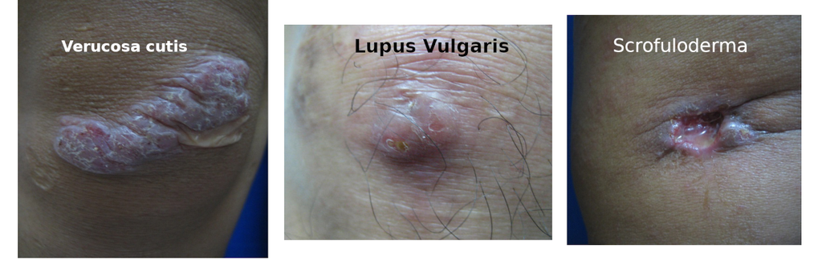